# Data Science Capstone Project Report

"Gert De Geyter"  
"Sunday, November 22, 2015"

### Capstone project

The main focus of this report is based on identifying the relations users have to prefer certain businesses and traits like romantic, trendy, etc. and dietary restrictions.

In this project we use the data made public for the [Yelp Dataset Challenge](http://www.yelp.com/dataset_challenge)

The code and full report are available on my personal [GitHub](https://github.com/gdgeyter/CapstoneYelp)

### Data merging and aggregating

As a first part of the project we combine the information coming from three different data sources. Below a schematic overview of merging and linking the datasets is shown.

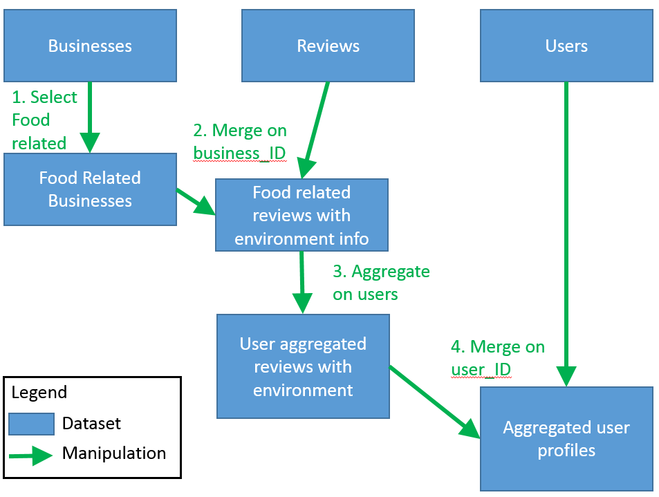

### Correlation

After obtaining the final data set we use the correlation matrix to look for tendencies of traits to pair up. Of course this correlation is first weighted by the amount of users writing reviews on business with these traits as well as the total amount of businesses having these traits.

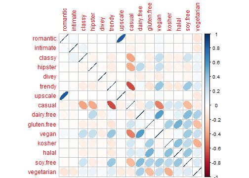

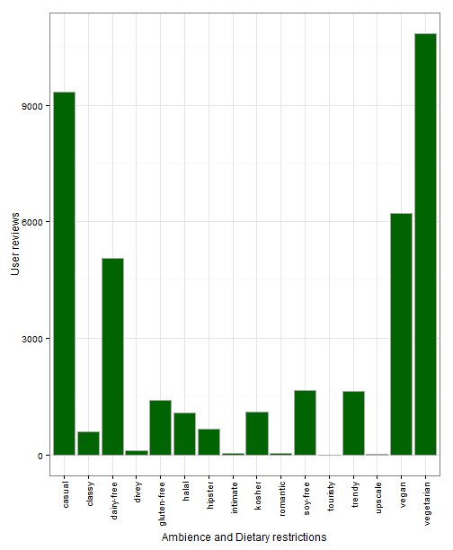

### Results and discussion

First *Correlation is not causation*. Therefore, one should **ALWAYS** we very careful when drawing conclusions from them. Because of this, and because of the smaller scale of this project, all the conclusions here will be expressed very conservativaly and should also be regarded as such.

When looking at previous slide we notice a few things:

- Not suprisingly there is a high tendency for dietary restrictions to pair up.
- Romantic users tend to be more upscale. This might not be so suprising as most people won't take their dates out on a cheap, fast-food restaurant.
- Trendy people are more likely to be vegan and eat soy free.
- Casual users are less likely to be classy, hispters or trendy.

Having this information could be an important tool for some businesses to adjust more to their clients needs. For example, using the second conclusion, upscale restaurants could focus specifically on advertising romantic dinners for two.

This is just a small example of the amount of information that could be locked in this data set alone so imagine what could be learned if it was enriched with other data like geospatial information of social network interests.